```r
library(dplyr)
library(completejourney)
```

```r
library(ggplot2)
library(stats4)
library(readr)
library(stringr)
library(tidyverse)
```

# Table import

```r
transactions <- get_transactions()
promotions <- get_promotions()
products <- products
demographics <- demographics

transactions
```

```
## # A tibble: 1,469,307 × 11
##    household_id store_id basket_id   product_id quantity sales_value retail_disc
##    <chr>        <chr>    <chr>       <chr>         <dbl>       <dbl>       <dbl>
##  1 900          330      31198570044 1095275           1        0.5         0
##  2 900          330      31198570047 9878513           1        0.99        0.1
##  3 1228         406      31198655051 1041453           1        1.43        0.15
##  4 906          319      31198705046 1020156           1        1.5         0.29
##  5 906          319      31198705046 1053875           2        2.78        0.8
##  6 906          319      31198705046 1060312           1        5.49        0.5
##  7 906          319      31198705046 1075313           1        1.5         0.29
##  8 1058         381      31198676055 985893            1        1.88        0.21
##  9 1058         381      31198676055 988791            1        1.5         1.29
## 10 1058         381      31198676055 9297106           1        2.69        0
## # ℹ 1,469,297 more rows
## # ℹ 4 more variables: coupon_disc <dbl>, coupon_match_disc <dbl>, week <int>,
## #   transaction_timestamp <dttm>
```

```r
promotions
```

```
## # A tibble: 20,940,529 × 5
##    product_id store_id display_location mailer_location  week
##    <chr>      <chr>    <fct>            <fct>           <int>
##  1 1000050    316      9                0                   1
##  2 1000050    337      3                0                   1
##  3 1000050    441      5                0                   1
##  4 1000092    292      0                A                   1
##  5 1000092    293      0                A                   1
##  6 1000092    295      0                A                   1
##  7 1000092    298      0                A                   1
##  8 1000092    299      0                A                   1
##  9 1000092    304      0                A                   1
## 10 1000092    306      0                A                   1
## # ℹ 20,940,519 more rows
```

```r
products
```

```
## # A tibble: 92,331 × 7
##    product_id manufacturer_id department    brand  product_category product_type
##    <chr>      <chr>           <chr>         <fct>  <chr>            <chr>
##  1 25671      2               GROCERY       Natio… FRZN ICE         ICE - CRUSH…
##  2 26081      2               MISCELLANEOUS Natio… <NA>             <NA>
##  3 26093      69              PASTRY        Priva… BREAD            BREAD:ITALI…
##  4 26190      69              GROCERY       Priva… FRUIT - SHELF S… APPLE SAUCE
##  5 26355      69              GROCERY       Priva… COOKIES/CONES    SPECIALTY C…
##  6 26426      69              GROCERY       Priva… SPICES & EXTRAC… SPICES & SE…
##  7 26540      69              GROCERY       Priva… COOKIES/CONES    TRAY PACK/C…
##  8 26601      69              DRUG GM       Priva… VITAMINS         VITAMIN - M…
##  9 26636      69              PASTRY        Priva… BREAKFAST SWEETS SW GDS: SW …
## 10 26691      16              GROCERY       Priva… PNT BTR/JELLY/J… HONEY
## # ℹ 92,321 more rows
## # ℹ 1 more variable: package_size <chr>
```

```r
demographics
```

```
## # A tibble: 801 × 8
##    household_id age   income    home_ownership marital_status household_size
##    <chr>        <ord> <ord>     <ord>          <ord>          <ord>
##  1 1            65+   35-49K    Homeowner      Married        2
##  2 1001         45-54 50-74K    Homeowner      Unmarried      1
##  3 1003         35-44 25-34K    <NA>           Unmarried      1
##  4 1004         25-34 15-24K    <NA>           Unmarried      1
##  5 101          45-54 Under 15K Homeowner      Married        4
##  6 1012         35-44 35-49K    <NA>           Married        5+
##  7 1014         45-54 15-24K    <NA>           Married        4
##  8 1015         45-54 50-74K    Homeowner      Unmarried      1
##  9 1018         45-54 35-49K    Homeowner      Married        5+
## 10 1020         45-54 25-34K    Homeowner      Married        2
## # ℹ 791 more rows
## # ℹ 2 more variables: household_comp <ord>, kids_count <ord>
```

#After running some code on the data completejourney provided us, we found some interesting areas where Regork could look to increase revenue. Here are the top 10 products sold at greater than a 50% discount. We can see that chicken generates the most income for Regork. We think that TPOC (TOMATOES”,“ONIONS”,“CARROTS”,“POTATOES”) are an essential part of cooking chicken recipes like soups,stews,chicken fry,etc and there could be opportunity to create more revenue from transactions involving any tomato products.

```r
idea<-transactions %>%
  inner_join(products, by = "product_id") %>%
  inner_join(demographics, by = "household_id") %>%
  mutate(discount = retail_disc / (retail_disc + sales_value)) %>%
  mutate(sellingprice = sales_value/ quantity) %>%
  filter(discount > .50) %>%
  group_by(product_category)
#glimpse(idea)


  idea %>%
  summarize(total_sales = sum(sales_value),total_quantity = sum(quantity),total_spend = sum(sellingprice)) %>%
  arrange(desc(total_sales))
```

```
## # A tibble: 212 × 4
##    product_category       total_sales total_quantity total_spend
##    <chr>                        <dbl>          <dbl>       <dbl>
##  1 CHICKEN                      8982.           2978       5613.
##  2 PORK                         3507.            275       3080.
##  3 BEEF                         3004.            856       2204.
##  4 FRZN MEAT/MEAT DINNERS       2457.           1619       1844.
##  5 ICE CREAM/MILK/SHERBTS       1803.           1394       1508.
##  6 HOT DOGS                     1648.           1653        NaN
##  7 COLD CEREAL                  1247.            739       1005.
##  8 LUNCHMEAT                    1009.           1111        659.
##  9 TOMATOES                      997.            720        958.
## 10 CANDY - CHECKLANE             994.           3825        455.
## # ℹ 202 more rows
```

#On futher analysis we realised total sales is not uniform among these vegetables, carrots are selling the least and Tomatoes are selling the most at greater than 50% discount.So, if we club TPOC (TOMATOES”,“ONIONS”,“CARROTS”,“POTATOES”) together and give discounts it will encourage the customers to shop these item togetehr at better rates.

```r
idea %>%
  filter(product_category %in% c("TOMATOES","ONIONS","CARROTS","POTATOES")) %>%
   group_by(product_category) %>%

   summarize(total_sales = sum(sales_value),total_quantity = sum(quantity),total_spend = sum(sellingprice)) %>%
   arrange(desc(total_sales))
```

```
## # A tibble: 4 × 4
##   product_category total_sales total_quantity total_spend
##   <chr>                  <dbl>          <dbl>       <dbl>
## 1 TOMATOES               997.             720       958.
## 2 POTATOES               234.             158       205.
## 3 ONIONS                  67.8            122        64.6
## 4 CARROTS                 42.3             42        37.0
```

#To understand the shopper behaviour we are analysing combine sales volume for TPOC Month wise to understand shopper behaviour using sales data.It was interesting to see mar,aug,oct,dec have significantly less sales even after discount greater than 50%.

```r
idea %>%
  filter(product_category %in% c("TOMATOES","ONIONS","CARROTS","POTATOES","PEPPERS-ALL")) %>%
  mutate(Transaction_date = date(transaction_timestamp)) %>%
  mutate(month = month(transaction_timestamp, label = TRUE)) %>%

  group_by(month) %>%
  summarise(total_sales = sum(sales_value),total_spend = sum(sellingprice))
```

```
## # A tibble: 9 × 3
##   month total_sales total_spend
##   <ord>       <dbl>       <dbl>
## 1 Mar          2.69        1.34
## 2 Apr        217.        213.
## 3 May        364.        327.
## 4 Jun        265.        263.
## 5 Jul        143.        141.
## 6 Aug         85.0        83.8
## 7 Oct         11.4         9.93
## 8 Nov        212.        189.
## 9 Dec         41.8        37.8
```

#We have done few more analysis based on Age,Household size, Household composition and income to understand the trend of shoppers categories which buy TPOC.

```r
#based on age shopper behaviour to buy these item

tomatoes_by_age <- transactions %>%
inner_join(products, by = "product_id") %>%
inner_join(demographics, by = "household_id") %>%
mutate(discount = retail_disc / (retail_disc + sales_value)) %>%
filter(discount > .50) %>%
filter(product_category %in% c("TOMATOES","ONIONS","CARROTS","POTATOES")) %>%
mutate(Transaction_date = date(transaction_timestamp)) %>%
mutate(month = month(transaction_timestamp, label = TRUE)) %>%
select(month, sales_value, age) %>%   group_by(age) %>%
summarise(total_sales = sum(sales_value)) %>%
arrange(desc(total_sales))

tomatoes_by_age
```

```
## # A tibble: 6 × 2
##   age   total_sales
##   <ord>       <dbl>
## 1 45-54       526.
## 2 35-44       311.
## 3 65+         189.
## 4 25-34       174.
## 5 55-64        97.6
## 6 19-24        43.4
```

[figure not shown]

```r
ggplot(tomatoes_by_age, aes(x = age, y = total_sales)) +
geom_bar(stat = "identity", fill = "blue") +
labs(title = "Total Sales of During Summer per Age Group",x = "Age Group", y = "Total Sales")
```

```r
#Based on household size shopper behaviour

tomatoes_by_household_size <- transactions %>%
inner_join(products, by = "product_id") %>%
inner_join(demographics, by = "household_id") %>%
mutate(discount = retail_disc / (retail_disc + sales_value)) %>%
filter(discount > .50) %>%
filter(product_category %in% c("TOMATOES","ONIONS","CARROTS","POTATOES")) %>%
mutate(Transaction_date = date(transaction_timestamp)) %>%
mutate(month = month(transaction_timestamp, label = TRUE)) %>%
select(month, sales_value, household_size) %>%   group_by(household_size) %>%
summarise(total_sales = sum(sales_value)) %>%
arrange(desc(total_sales))

tomatoes_by_household_size
```

```
## # A tibble: 5 × 2
##   household_size total_sales
##   <ord>                <dbl>
## 1 2                    581.
## 2 1                    426.
## 3 3                    148.
## 4 5+                   101.
## 5 4                     85.2
```

```r
tomatoes_by_household_comp <- transactions %>%
inner_join(products, by = "product_id") %>%
inner_join(demographics, by = "household_id") %>%
mutate(discount = retail_disc / (retail_disc + sales_value)) %>%
filter(discount > .50) %>%
filter(product_category %in% c("TOMATOES","ONIONS","CARROTS","POTATOES")) %>%
mutate(Transaction_date = date(transaction_timestamp)) %>%
mutate(month = month(transaction_timestamp, label = TRUE)) %>%
select(month, sales_value, household_comp) %>%   group_by(household_comp) %>%
summarise(total_sales = sum(sales_value)) %>%
arrange(desc(total_sales))

tomatoes_by_household_comp
```

```
## # A tibble: 4 × 2
##   household_comp   total_sales
##   <ord>                  <dbl>
## 1 2 Adults No Kids        467.
## 2 1 Adult No Kids         426.
## 3 2 Adults Kids           284.
## 4 1 Adult Kids            164.
```

#Income Ranges of 35-49k and 50-74k are the two close leaders in purchasing tomato-related products when they’re discounted over 50%.

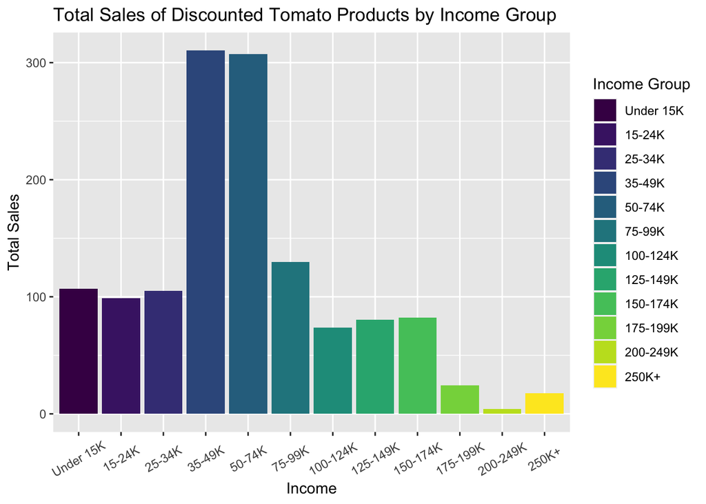

```r
transactions %>%
  inner_join(products, by = "product_id") %>%
  inner_join(demographics, by = "household_id") %>%
  mutate(discount = retail_disc / (retail_disc + sales_value)) %>%
  filter(discount > .50) %>%
  filter(product_category %in% c("TOMATOES","ONIONS","CARROTS","POTATOES")) %>%
  mutate(Transaction_date = date(transaction_timestamp)) %>%
  mutate(month = month(transaction_timestamp, label = TRUE)) %>%
  group_by(income) %>%
  summarise(total_sales = sum(sales_value)) %>%
  arrange(desc(total_sales)) %>%
  ggplot(aes(x = income, y = total_sales, fill = income)) +
  geom_col() +
  labs(title = "Total Sales of Discounted Tomato Products by Income Group", x = "Income", y = "Total Sales", fill = "Income Group") +
  theme(axis.text.x = element_text(angle = 30, hjust = 0.5, vjust = 0.5))
```

```r
transactions %>%
  inner_join(products, by = "product_id") %>%
  inner_join(demographics, by = "household_id") %>%
  mutate(discount = retail_disc / (retail_disc + sales_value)) %>%
  filter(discount > .50) %>%
  filter(product_category %in% c("TOMATOES","ONIONS","CARROTS","POTATOES")) %>%
  group_by(product_type) %>%
  summarize(total_sales = sum(sales_value)) %>%
  arrange(desc(total_sales))
```

```
## # A tibble: 13 × 2
##    product_type                  total_sales
##    <chr>                               <dbl>
##  1 TOMATOES HOTHOUSE ON THE VINE      672.
##  2 TOMATOES VINE RIPE BULK            210.
##  3 POTATOES SWEET&YAMS                145.
##  4 TOMATOES GRAPE                     113
##  5 POTATOES RUSSET (BULK&BAG)          87.0
##  6 ONIONS SWEET (BULK&BAG)             55.8
##  7 CARROTS MINI PEELED                 42.3
##  8 ONIONS RED (BULK&BAG)                5.36
##  9 ONIONS WHITE (BULK&BAG)              4.04
## 10 ONIONS YELLOW (BULK&BAG)             2.6
## 11 POTATOES RED (BULK&BAG)              1.49
## 12 TOMATOES CHERRY                      0.99
## 13 ROMA TOMATOES (BULK/PKG)             0.4
```

**Based on the trends on various factors mentioned above we have two recommendations for the CEO** #Recommendation 1 #Sales team should reach out to the brands that make the ONIONS WHITE (BULK&BAG)  
ONIONS YELLOW (BULK&BAG)  
POTATOES RED (BULK&BAG)  
TOMATOES CHERRY  
ROMA TOMATOES (BULK/PKG)  
#so if they could offer a better whole-sale price to hopefully sell more discounted tomatoes.

#Recommendation 2 # Marketing team should run few creative campaigns to sells TPOC as a combo in the mar,aug,oct,dec for a competitive price to improve month wise revenue.